# Building a Convolutional Neural Network (CNN) from Scratch with NumPy

## Project Overview

This project demonstrates a fully functional convolutional neural network (CNN) implemented from scratch using only NumPy — no deep learning libraries like TensorFlow or PyTorch. Once upon a time an interviewer wanted an in-depth description of a CNN... my answer was *a little questionable*, so I have set out to deepen my understanding of CNNs.

The model is trained on a subset of the [EuroSAT dataset](https://www.kaggle.com/datasets/apollo2506/eurosat-dataset), which contains satellite images classified into various land use categories.

This is not meant to achieve state-of-the-art accuracy, but to reinforce a deep understanding of CNN architecture and implementation details. Also, running image classification on CPU takes forever.

## Goals

- Implement core CNN operations from scratch: convolution, ReLU, max pooling, flattening, fully connected layer, softmax, and cross-entropy loss.
- Add backpropagation for training.
- Train and evaluate the model on EuroSAT data.
- Keep training simple enough to run on CPU in reasonable time.

```python
import os
import numpy as np
from PIL import Image
import matplotlib.pyplot as plt
from sklearn.model_selection import train_test_split
from sklearn.preprocessing import LabelEncoder
from sklearn.utils import shuffle
```

## Dataset

The EuroSAT dataset consists of RGB satellite images of size 64×64 pixels across 10 classes. For this project, I selected 4 classes:

- `River`
- `Residential`
- `Forest`
- `SeaLake`

To keep training fast on CPU, I limited the dataset to 100 samples per class (400 total), then split it 80/20 for training/testing.

```python
dataset_path = ".../EuroSAT"
classes = sorted(os.listdir(dataset_path))
selected_classes = ['River', 'Residential', 'Forest', 'SeaLake']

image_size = (64, 64)
samples_per_class = 100
X = []
y = []

for label_index, class_name in enumerate(selected_classes):
    class_dir = os.path.join(dataset_path, class_name)
    image_files = [f for f in os.listdir(class_dir) if f.endswith(".jpg")]
    image_files = image_files[:samples_per_class]  # Truncate to limit

    for filename in image_files:
        img_path = os.path.join(class_dir, filename)
        img = Image.open(img_path).resize(image_size)
        img_array = np.array(img) / 255.0  # Normalize
        img_array = img_array.transpose(2, 0, 1)  # HWC to CHW
        X.append(img_array)
        y.append(label_index)

X = np.array(X)  # shape (num_samples, 3, 64, 64)
y = np.array(y)  # shape (num_samples,)
print("X shape:", X.shape)
print("y shape:", y.shape)
```

```
X shape: (400, 3, 64, 64)
y shape: (400,)
```

```python
X_train, X_test, y_train, y_test = train_test_split(
    X, y, test_size=0.2, random_state=42, stratify=y
)
```

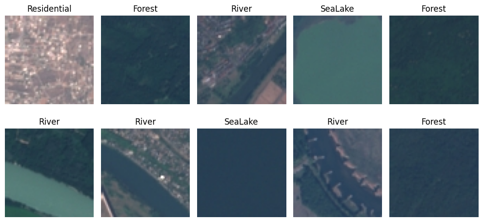

```python
plt.figure(figsize=(10, 5))
for i in range(10):
    plt.subplot(2, 5, i+1)
    plt.imshow(X_train[i].transpose(1,2,0))
    plt.title(selected_classes[y_train[i]])
    plt.axis('off')
plt.tight_layout()
plt.show()
```

## Implementing the Forward Pass

Let's implement the forward components of the CNN:

- Convolution
- ReLU
- Max Pooling
- Flatten
- Dense layer
- Softmax

```python
def conv2d_forward(X, W, b, stride=1, padding=0):
    """
    Perform a 2D convolution operation on the input image or feature map.

    Parameters:
    ----------
    X : np.ndarray
        Input feature map of shape (channel_in, height_in, width_in)
    W : np.ndarray
        Filters of shape (num_filters, channel_in, filter_height, filter_width)
    b : np.ndarray
        Biases of shape (num_filters,)
    stride : int
        Stride of the convolution operation.
    padding : int
        Number of zero-padding pixels to add to height and width.

    Returns:
    -------
    out : np.ndarray
        Output feature map of shape (num_filters, height_out, width_out)
    """

    # Input dimensions
    channel_in, height_in, width_in = X.shape

    # Filter dimensions
    num_filters, _, filter_height, filter_width = W.shape

    # Pad zeros around the height and width of the input
    X_padded = np.pad(X, ((0, 0), (padding, padding), (padding, padding)), mode='constant')

    # Output dimensions after convolution
    height_out = (height_in + 2 * padding - filter_height) // stride + 1
    width_out = (width_in + 2 * padding - filter_width) // stride + 1

    # Initialize output feature map with zeros
    out = np.zeros((num_filters, height_out, width_out))

    # Loop over each filter
    for f in range(num_filters):
        # Loop over each vertical and horizontal output position
        for i in range(height_out):
            for j in range(width_out):
                # Calculate the slice coordinates on the input
                height_start = i * stride
                height_end = height_start + filter_height
                width_start = j * stride
                width_end = width_start + filter_width

                # Extract the patch and perform element-wise multiplication
                patch = X_padded[:, height_start:height_end, width_start:width_end]

                # Perform element-wise multiplication and add the bias for this filter
                out[f, i, j] = np.sum(patch * W[f]) + b[f]

    return out
```

```python
def relu_forward(X):
    """
    Apply ReLU activation function element-wise.

    Parameters:
    ----------
    X : np.ndarray
        Input array (any shape)

    Returns:
    -------
    out : np.ndarray
        Output array where all negative values are replaced with 0
    """
    return np.maximum(X, 0)
```

```python
def maxpool_forward(X, pool_size=2, stride=2):
    """
    Perform max pooling operation on the input feature map.

    Parameters:
    ----------
    X : np.ndarray
        Input feature map of shape (channel, height, width)
    pool_size : int
        Size of the pooling window (assumes square window)
    stride : int
        Step size for moving the pooling window

    Returns:
    -------
    out : np.ndarray
        Downsampled feature map of shape (C, H_out, W_out)
    """

    # Input dimensions
    channel_in, height_in, width_in = X.shape

    # Output dimensions
    height_out = (height_in - pool_size) // stride + 1
    width_out = (width_in - pool_size) // stride + 1

    # Initialize output array
    out = np.zeros((channel_in, height_out, width_out))

    # Loop over each channel
    for c in range(channel_in):
        # Loop over each vertical and horizontal output position
        for i in range(height_out):
            for j in range(width_out):
                height_start = i * stride
                height_end = height_start + pool_size
                width_start = j * stride
                width_end = width_start + pool_size

                # Extract patch and assign the max to the output
                patch = X[c, height_start:height_end, width_start:width_end]
                out[c, i, j] = np.max(patch)
    return out
```

```python
def flatten_forward(X):
    """
    Flatten a multi-dimensional tensor into a 1D vector.

    Parameters:
    ----------
    X : np.ndarray
        Input array of shape (C, H, W) or similar

    Returns:
    -------
    out : np.ndarray
        Flattened array of shape (C * H * W,)
    """
    return X.reshape(-1)
```

```python
def dense_forward(X, W, b):
    """
    Compute the output of a fully connected (dense) layer.

    Parameters:
    ----------
    X : np.ndarray
        Input vector of shape (input_dim,)
    W : np.ndarray
        Weight matrix of shape (output_dim, input_dim)
    b : np.ndarray
        Bias vector of shape (output_dim,)

    Returns:
    -------
    out : np.ndarray
        Output vector of shape (output_dim,)
    """
    return np.dot(W, X) + b
```

```python
def softmax(logits):
    """
    Compute softmax probabilities from logits.

    Parameters:
    ----------
    logits : np.ndarray
        Input scores (unnormalized) of shape (num_classes,)

    Returns:
    -------
    probs : np.ndarray
        Probability distribution of shape (num_classes,)
    """

    # Shift logits for numerical stability
    shifted_logits = logits - np.max(logits)

    # Exponentiate
    exp_scores = np.exp(shifted_logits)

    # Normalize to get probabilities
    probs = exp_scores / np.sum(exp_scores)

    return probs
```

## Implementing Backpropagation

Next, I implemented the backward versions of each function to support gradient-based learning:

- `conv2d_backward`
- `relu_backward`
- `maxpool_backward`
- `flatten_backward`
- `dense_backward`
- Gradient of softmax + cross entropy

```python
def dense_backward(dense_out, X, W):
    """
    Backward pass for a dense (fully connected) layer.

    Parameters
    ----------
    dense_out : np.ndarray
        Gradient of loss w.r.t. output of dense layer, shape (output_dim,)
    X : np.ndarray
        Input to the dense layer, shape (input_dim,)
    W : np.ndarray
        Weight matrix used in forward pass, shape (output_dim, input_dim)

    Returns
    -------
    dX : np.ndarray
        Gradient w.r.t. input X, shape (input_dim,)
    dW : np.ndarray
        Gradient w.r.t. weights W, shape (output_dim, input_dim)
    db : np.ndarray
        Gradient w.r.t. biases, shape (output_dim,)
    """

    # Gradient of weights: outer product of dense_out and input
    dW = np.outer(dense_out, X)

    # Gradient of biases is just dense_out
    db = dense_out

    # Gradient of input: backprop through linear layer
    dX = W.T @ dense_out  # use @ for matrix multiplication
    return dX, dW, db
```

```python
def flatten_backward(dense_out, input_shape):
    """
    Reverse the flatten operation to return gradient to original shape.

    Parameters
    ----------
    dense_out : np.ndarray
        Gradient after flatten layer, shape (flattened_dim,)
    input_shape : tuple
        Original input shape before flatten, e.g., (channel, height, width)

    Returns
    -------
    dX : np.ndarray
        Gradient reshaped to input_shape
    """
    # Reshape the flat gradient back to the original shape
    return dense_out.reshape(input_shape)
```

```python
def maxpool_backward(dense_out, X, pool_size=2, stride=2):
    """
    Backward pass for max pooling.

    Parameters
    ----------
    dense_out : np.ndarray
        Gradient of loss w.r.t. pooled output, shape (channel, height_out, width_out)
    X : np.ndarray
        Input to the pooling layer from forward pass, shape (channel, height, width)
    pool_size : int
        Size of the pooling window
    stride : int
        Stride used during pooling

    Returns
    -------
    dX : np.ndarray
        Gradient w.r.t. input X, same shape as X
    """

    channel, height, width = X.shape
    height_out = (height - pool_size) // stride + 1
    width_out = (width - pool_size) // stride + 1
    dX = np.zeros_like(X)

    for c in range(channel):
        for i in range(height_out):
            for j in range(width_out):
                height_start = i * stride
                height_end = height_start + pool_size
                width_start = j * stride
                width_end = width_start + pool_size

                # Extract the pooling region
                patch = X[c, height_start:height_end, width_start:width_end]
                # Create mask of max location
                mask = (patch == np.max(patch))
                # Route the gradient to where the max occurred
                dX[c, height_start:height_end, width_start:width_end] += dense_out[c, i, j] * mask
    return dX
```

```python
def relu_backward(dense_out, X):
    """
    Backward pass for ReLU activation.

    Parameters
    ----------
    dense_out : np.ndarray
        Gradient from next layer, same shape as input X
    X : np.ndarray
        Input to ReLU layer (pre-activation), shape (any)

    Returns
    -------
    dX : np.ndarray
        Gradient w.r.t. input X
    """
    # Pass the gradient through where input was positive
    dX = dense_out * (X > 0)
    return dX
```

```python
def conv2d_backward(dense_out, X, W, stride=1, padding=0):
    """
    Backward pass for 2D convolution.

    Parameters
    ----------
    dense_out : np.ndarray
        Gradient of loss w.r.t. conv output, shape (F, height_out, width_out)
    X : np.ndarray
        Input to the conv layer, shape (channel_in, height_in, width_in)
    W : np.ndarray
        Convolution weights, shape (F, channel_in, KH, KW)
    stride : int
        Stride used in conv forward
    padding : int
        Padding used in conv forward

    Returns
    -------
    dX : np.ndarray
        Gradient w.r.t. input X, shape (channel_in, height_in, width_in)
    dW : np.ndarray
        Gradient w.r.t. weights W, shape (F, channel_in, KH, KW)
    db : np.ndarray
        Gradient w.r.t. biases, shape (F,)
    """
    F, channel_in, KH, KW = W.shape
    _, height_out, width_out = dense_out.shape
    channel_in, height_in, width_in = X.shape

    # Pad the input if padding was used during the forward pass
    if padding > 0:
        X_padded = np.pad(X, ((0, 0), (padding, padding), (padding, padding)), mode='constant')
    else:
        X_padded = X

    dX_padded = np.zeros_like(X_padded)
    dW = np.zeros_like(W)
    db = np.zeros(F)

    for f in range(F):
        # Accumulate bias gradients
        db[f] = np.sum(dense_out[f])
        for i in range(height_out):
            for j in range(width_out):
                height_start = i * stride
                height_end = height_start + KH
                width_start = j * stride
                width_end = width_start + KW

                # Slice the input region
                patch = X_padded[:, height_start:height_end, width_start:width_end]
                # Compute gradients
                dW[f] += dense_out[f, i, j] * patch
                dX_padded[:, height_start:height_end, width_start:width_end] += dense_out[f, i, j] * W[f]

    # Remove padding from the input gradient
    if padding > 0:
        dX = dX_padded[:, padding:-padding, padding:-padding]
    else:
        dX = dX_padded

    return dX, dW, db
```

```python
def softmax_cross_entropy_backward(probs, label):
    """
    Gradient of cross-entropy loss w.r.t. logits (after softmax).

    Parameters
    ----------
    probs : np.ndarray
        Softmax probabilities from forward pass, shape (num_classes,)
    label : int
        Ground truth class index

    Returns
    -------
    dlogits : np.ndarray
        Gradient of loss w.r.t. logits, shape (num_classes,)
    """
    # Subtract 1 at the true class position (softmax + cross entropy loss gradient)
    dlogits = probs.copy()
    dlogits[label] -= 1
    return dlogits
```

## Combine Everything and Train the Model

```python
def train_epoch(X_train, y_train, model, lr=0.01):
    """
    Train the CNN model for one epoch.

    Parameters:
    ----------
    X_train : list of np.ndarray
        List of input images of shape (channel, height, width)
    y_train : list or np.ndarray
        Corresponding labels
    model : dict
        Dictionary containing model parameters and cache
    lr : float
        Learning rate
    """
    for X, y in zip(X_train, y_train):
        # ----------------------------
        # Forward Pass
        # ----------------------------
        out = X
        model['cache'] = {}

        # Conv -> ReLU -> MaxPool
        out = conv2d_forward(out, model['conv_W'], model['conv_b'], stride=1, padding=1)
        model['cache']['conv_out'] = out
        out = relu_forward(out)
        model['cache']['relu_out'] = out
        out = maxpool_forward(out, pool_size=2, stride=2)
        model['cache']['pool_out'] = out

        # Flatten -> Dense -> Softmax
        model['cache']['flat_input_shape'] = out.shape
        out = flatten_forward(out)
        model['cache']['flat_out'] = out
        logits = dense_forward(out, model['dense_W'], model['dense_b'])
        probs = softmax(logits)

        # ----------------------------
        # Backward Pass
        # ----------------------------
        dlogits = softmax_cross_entropy_backward(probs, y)
        dflat_out, dW_dense, db_dense = dense_backward(dlogits, model['cache']['flat_out'], model['dense_W'])
        dpool_out = flatten_backward(dflat_out, model['cache']['flat_input_shape'])
        drelu_out = maxpool_backward(dpool_out, model['cache']['relu_out'])
        dconv_out = relu_backward(drelu_out, model['cache']['conv_out'])
        dX, dW_conv, db_conv = conv2d_backward(dconv_out, X, model['conv_W'], stride=1, padding=1)

        # ----------------------------
        # Update Weights
        # ----------------------------
        model['conv_W'] -= lr * dW_conv
        model['conv_b'] -= lr * db_conv
        model['dense_W'] -= lr * dW_dense
        model['dense_b'] -= lr * db_dense
```

```python
def initialize_model(num_classes=4):
    model = {}

    # Conv layer: 3 input channels, 8 filters, 3x3 kernel
    model['conv_W'] = np.random.randn(8, 3, 3, 3) * 0.1
    model['conv_b'] = np.zeros(8)

    # After conv+relu+maxpool, the feature map size is (8, 32, 32)
    # Flattened size is 8*32*32 = 8192
    model['dense_W'] = np.random.randn(num_classes, 8 * 32 * 32) * 0.01
    model['dense_b'] = np.zeros(num_classes)

    return model
```

```python
def evaluate_accuracy(X_data, y_data, model):
    correct = 0
    for i in range(len(X_data)):
        pred = predict(X_data[i], model)
        if pred == y_data[i]:
            correct += 1
    return correct / len(X_data)
```

```python
def predict(X, model):
    """
    Predict label for a single input sample X (C, H, W)
    """
    out = conv2d_forward(X, model['conv_W'], model['conv_b'], stride=1, padding=1)
    out = relu_forward(out)
    out = maxpool_forward(out, pool_size=2, stride=2)
    out = flatten_forward(out)
    logits = dense_forward(out, model['dense_W'], model['dense_b'])
    probs = softmax(logits)
    return np.argmax(probs)
```

```python
# Initialize
model = initialize_model()
num_epochs = 8

for epoch in range(num_epochs):
    print(f"Epoch {epoch+1}")
    for i in range(len(X_train)):
        train_epoch([X_train[i]], [y_train[i]], model, lr=0.03)

    # Optional: evaluate every epoch
    acc = evaluate_accuracy(X_test, y_test, model)
    print(f"Test Accuracy after epoch {epoch+1}: {acc:.4f}")
```

```
Epoch 1
Test Accuracy after epoch 1: 0.2500
Epoch 2
Test Accuracy after epoch 2: 0.4500
Epoch 3
Test Accuracy after epoch 3: 0.2625
Epoch 4
Test Accuracy after epoch 4: 0.4750
Epoch 5
Test Accuracy after epoch 5: 0.4750
Epoch 6
Test Accuracy after epoch 6: 0.3000
Epoch 7
Test Accuracy after epoch 7: 0.2875
Epoch 8
Test Accuracy after epoch 8: 0.4375
```

## Results and Reflection

- Accuracy peaked at 47.5%... obviously not great, but that was not the purpose of this project. Also, metrics such as precision and recall would be favored if this was an actual implementation.
- The accuracy is limited by:
  - Small dataset (100 images per class)
  - Simple architecture (1 conv layer)
  - No data augmentation or regularization
- Still, this is a functional CNN trained purely with NumPy, and it highlights the mechanics of deep learning from the ground up.